# README

Xinzhe Dong November 13, 2017

In this assignment, I will build an automated data analysis pipline using two methods: the master R script `Makefile.R` and `Makefile`. Here is the [link](http://stat545.com/hw07_automation.html) to the homework on the course webpage.

**Dependency Diagram:**

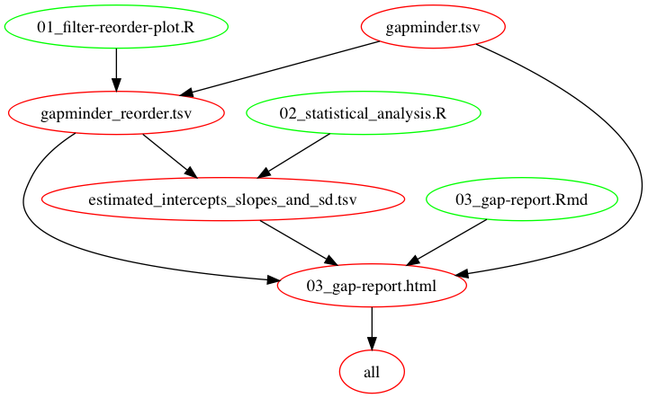

**Link to Project files:**

**R scripts:**

[`00_download-data.R`](https://github.com/hannahdxz/STAT545-hw-Dong-Xinzhe/blob/master/hw%2007/00_download-data.R) download the raw data for our example, `gapminder.tsv`.

[`01_filter-reorder-plot.R`](https://github.com/hannahdxz/STAT545-hw-Dong-Xinzhe/blob/master/hw%2007/01_filter-reorder-plot.R)

- Bring the data in as data frame.
- Make some plots, save to file a boxplot of lifeExp and continents, and a scatterplot of lifeExp vs. year.
- Reorder Gapminder continents by minimum of lifeExp, and write the reordered data to file.

[`02_statistical_analysis.R`](https://github.com/hannahdxz/STAT545-hw-Dong-Xinzhe/blob/master/hw%2007/02_statistical_analysis.R)

- Fit a linear regression of life expectancy on year within each country. Write the estimated intercepts, slopes, and std.error to file.
- Create a scatterplots of life expectancy vs. year for the 4 countries with large std.error found in each continent, fitted line overlaid, and write these plots to file.

[`03_gap-report.Rmd`](https://github.com/hannahdxz/STAT545-hw-Dong-Xinzhe/blob/master/hw%2007/03_gap-report.Rmd)

- a Rmarkdown document.
- Its purpose is to allow us to demonstrate how to use `rmarkdown::render()` without the help of RStudio’s buttons. We will call `rmarkdown::render()` from within a `Makefile`.
- This [`03_gap-report.md`](https://github.com/hannahdxz/STAT545-hw-Dong-Xinzhe/blob/master/hw%2007/03_gap-report.md) is the rendered report.

**Master R scripts:**

[`Makefile.R`](https://github.com/hannahdxz/STAT545-hw-Dong-Xinzhe/blob/master/hw%2007/Makefile.R) is a master R script that simply `source()`s the three scripts (`00_download-data.R`, `01_filter-reorder-plot.R`, and `02_statistical_analysis.R`), one after the other, with a “clean up / reset” line that deletes all the output the scripts leave behind.

[`render_r_scripts.R`](https://github.com/hannahdxz/STAT545-hw-Dong-Xinzhe/blob/master/hw%2007/render_r_scripts.R) render the `Makefile.R` and `03_gap-report.Rmd` and emulate RStudio’s “Compile Notebook” and “Knit HTML” button.

**Makefile:**

[`Makefile`](https://github.com/hannahdxz/STAT545-hw-Dong-Xinzhe/blob/master/hw%2007/Makefile) to automate the pipeline using `make`.

- run the Rscripts (`00_download-data.R`, `01_filter-reorder-plot.R`, `02_statistical_analysis.R`,`03_gap-report.Rmd`)
- render an Rscript, use `Rscript -e "rmarkdown::render('01_filter-reorder-plot.R')"`
- render an RMarkdown report, use `Rscript -e "rmarkdown::render('03_gap-report.Rmd')"`